# STAT/MATH 495: Problem Set 07

Harrison Marick

2017-10-24

Information on the competition can be found [here](https://www.kaggle.com/c/GiveMeSomeCredit/data).

# Collaboration

Please indicate who you collaborated with on this assignment:

I ride solo.

# Build binary classifier

Build the binary classifier based on a single predictor variable: `DebtRatio`, `age`, or `MonthlyIncome`. Justify this choice.

```r
colnames(train)[c(5,11)]=c("late1", "late2") #renaming the NumberOfTime30-59Days... column
colnames(test)[c(5,11)]=c("late1", "late2") #renaming the NumberOfTime60-89Days... column
```

In my exploration of this dataset, I examined various boxplots that indicated the relationship between quantitative variables and our classifier response variable. Below is the boxplot for age, broken down by delinquency status.

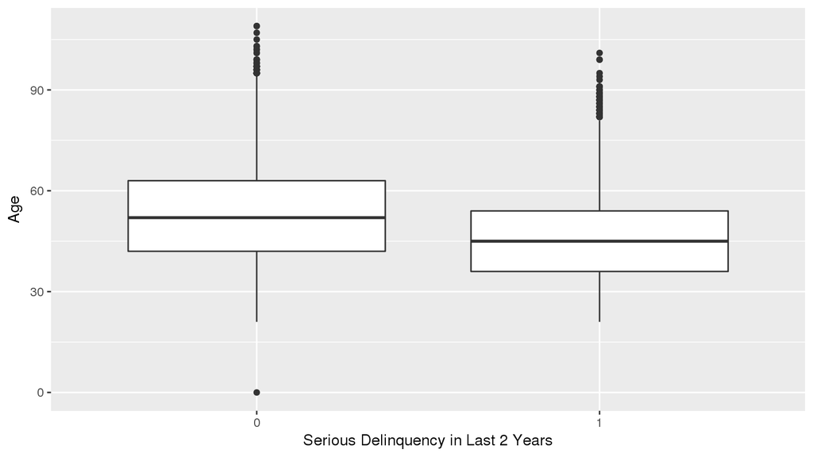

```r
ggplot(train, aes(as.factor(SeriousDlqin2yrs), age)) + geom_boxplot() +
  xlab("Serious Delinquency in Last 2 Years") +
  ylab("Age")
```

Before selecting this variable as my predictor of choice, I further investigated by looking at the rate of delinquency by the Age.

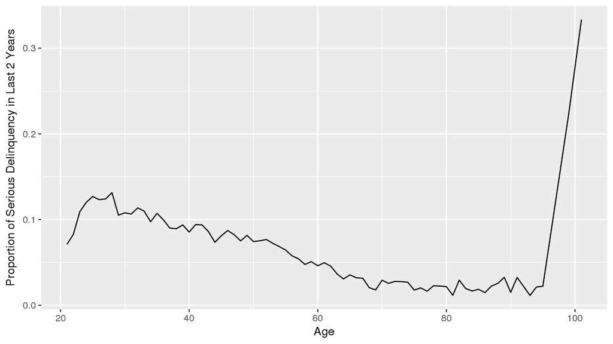

```r
proportions <- train %>%
  group_by(SeriousDlqin2yrs, age) %>%
  summarise(n=n()) %>%
  # Create new grouping structure to compute proportions:
  group_by(age) %>%
  mutate(prop = n/sum(n)) %>%
  filter(SeriousDlqin2yrs==1)

ggplot(proportions, aes(x=age, y=prop)) +
  geom_line() +
  ylab("Proportion of Serious Delinquency in Last 2 Years") +
  xlab("Age")
```

As we increase the X value, however, the rate of delinquency decreases. This is another indication that age is a good predictor of delinquency. Below, we have fit a logistic model with age as our predictor.

```r
mod<-glm(SeriousDlqin2yrs~age, data=train, family="binomial")
log_odds_hat <- predict(mod, newdata=test)
p_hat <- 1/(1 + exp(-log_odds_hat))

test$Probability=p_hat
submission<-test[,c(1,13)] #selecting specific columns
write.csv(submission, "submission.csv", row.names = FALSE)
```

# ROC curve

Based on the ultimate classifier you choose, plot a corresponding ROC curve.

```r
train_aug <- mod %>%
  broom::augment() %>%
  as_tibble() %>%
  mutate(p_hat = 1/(1+exp(-.fitted)))

library(ROCR)
# This bit of code computes the ROC curve
pred <- prediction(predictions = train_aug$p_hat, labels = train_aug$SeriousDlqin2yrs)
perf <- performance(pred, "tpr","fpr")

# This bit of code computes the Area Under the Curve
auc <- as.numeric(performance(pred,"auc")@y.values)
auc
```

```
## [1] 0.6352512
```

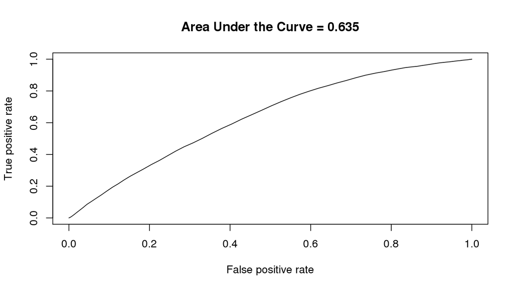

```r
plot(perf, main=paste("Area Under the Curve =", round(auc, 3)))
```

# ROC curve for random guessing

Instead of using any predictor information as you did above, switch your predictions to random guesses and plot the resulting ROC curve.

```r
p_hat_random<-runif(length(train_aug$SeriousDlqin2yrs)) #draw from Unif(0,1) dist
pred <- prediction(predictions = p_hat_random, labels = train_aug$SeriousDlqin2yrs)
perf <- performance(pred, "tpr","fpr")

# This bit of code computes the Area Under the Curve
auc <- as.numeric(performance(pred,"auc")@y.values)
auc
```

```
## [1] 0.4973906
```

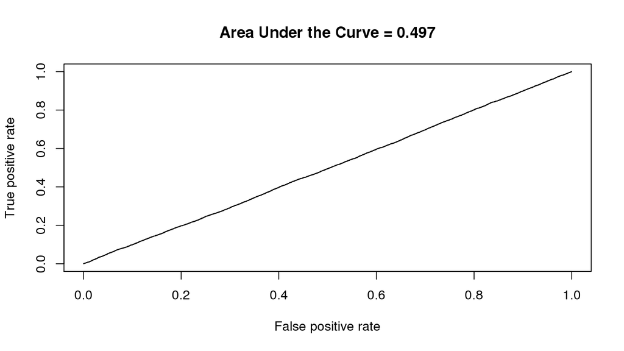

```r
plot(perf, main=paste("Area Under the Curve =", round(auc, 3)))
```